# FinalP

## Can Diabetes be Predicted by Lifestyle Choices?

### Adedamola Adeyemi

```python
#importing packages
import numpy as np
import pandas as pd
import matplotlib.pyplot as plt
import seaborn as sns
```

### DataSet Intro

Reading and comprehending the dataset. The data is fairly clean and organized, so I just had to change a few things for simplification. There is a lot of data present, some categorical and some numerical, and the data types make sense for the type of data being looked into. Having all these variables should make it easier to create a prediction model for diabetes. (At least that's what I would expected at this point)

```python
#reading the data, looking at the columns
df=pd.read_csv("diabetes_dataset.csv")
print(df.dtypes)

#Renaming a few columns
df.rename(columns={'HbA1c': 'Blood Sugar'}, inplace=True)

#Checking for duplicates
duplicated_data = df.duplicated().sum()
print(f'sum of duplicates:{duplicated_data}')

#Making sure I won't have any issues with weird spellings
df.apply(lambda x: x.str.contains(' ', regex=False).any() if x.dtype == "object" else False)
```

```
Unnamed: 0                         int64
Age                                int64
Sex                               object
Ethnicity                         object
BMI                              float64
Waist_Circumference              float64
Fasting_Blood_Glucose            float64
HbA1c                            float64
Blood_Pressure_Systolic            int64
Blood_Pressure_Diastolic           int64
Cholesterol_Total                float64
Cholesterol_HDL                  float64
Cholesterol_LDL                  float64
GGT                              float64
Serum_Urate                      float64
Physical_Activity_Level           object
Dietary_Intake_Calories            int64
Alcohol_Consumption               object
Smoking_Status                    object
Family_History_of_Diabetes         int64
Previous_Gestational_Diabetes      int64
dtype: object
sum of duplicates:0
```

```
Unnamed: 0                       False
Age                              False
Sex                              False
Ethnicity                        False
BMI                              False
Waist_Circumference              False
Fasting_Blood_Glucose            False
Blood Sugar                      False
Blood_Pressure_Systolic          False
Blood_Pressure_Diastolic         False
Cholesterol_Total                False
Cholesterol_HDL                  False
Cholesterol_LDL                  False
GGT                              False
Serum_Urate                      False
Physical_Activity_Level          False
Dietary_Intake_Calories          False
Alcohol_Consumption              False
Smoking_Status                   False
Family_History_of_Diabetes       False
Previous_Gestational_Diabetes    False
dtype: bool
```

```python
#Summarizing data info
df.describe(include='all')
df.describe(include="object")
```

|  | Sex | Ethnicity | Physical_Activity_Level | Alcohol_Consumption | Smoking_Status |
| --- | --- | --- | --- | --- | --- |
| count | 10000 | 10000 | 10000 | 6680 | 10000 |
| unique | 2 | 4 | 3 | 2 | 3 |
| top | Female | Black | Low | Moderate | Current |
| freq | 5005 | 2539 | 3372 | 3373 | 3364 |

```python
#Creating/adding age groups column
age_groups = [0, 17, 29, 45, 60, 200]
age_labels = ["Child/Teen", "Young Adult", "Adult", "Middle Aged", "Senior"]
df["Age_Group"] = pd.cut(df["Age"], bins=age_groups, labels=age_labels, right=True)

#Flagging for high blood pressure. (Based off typical ranges). Giving it a numerical tag (1=Flagged, 0= Not flagged)
df["High_BP_Flag"] = np.where((df["Blood_Pressure_Systolic"] >= 130) |
    (df["Blood_Pressure_Diastolic"] >= 80), 1, 0)
```

### Required Visuals

The next couple cells are the visuals required. They yield good info, but it takes some thinking to learn why. At the same time some of the info that comes from it is not very informative, such as the correlation heatmap below. The common trend in this area helps show why it is so hard to predict diabetes. Though there are so many different factors at play, every mode of visualization fails to show clear influence. Many variables express similar correlation and it makes is seem as if lifestyle and even some genetic factors do nothing to predict diabetes reliably.

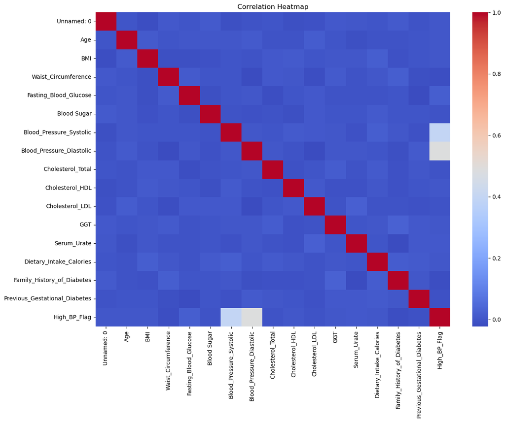

```python
#Correlation Heatmap
plt.figure(figsize=(14, 10))
sns.heatmap(df.select_dtypes(include=["float", "int"]).corr(), cmap="coolwarm", annot=False)
plt.title("Correlation Heatmap")
plt.show()
```

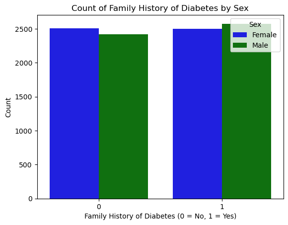

```python
#plt.figure(figsize=(8, 5))
sns.countplot(data=df, x="Family_History_of_Diabetes", hue="Sex",palette=["blue", "green"])
plt.title("Count of Family History of Diabetes by Sex")
plt.xlabel("Family History of Diabetes (0 = No, 1 = Yes)")
plt.ylabel("Count")
plt.show()
```

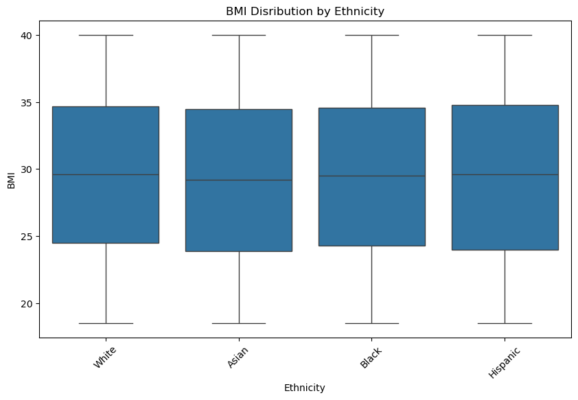

```python
#BMI by ethnicity
plt.figure(figsize=(10, 6))
sns.boxplot(data=df, x="Ethnicity", y="BMI")
plt.title("BMI Disribution by Ethnicity")
plt.xticks(rotation=45)
plt.show()
```

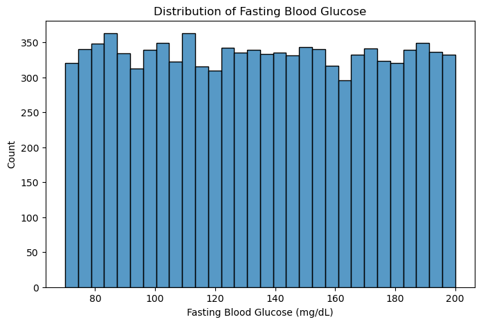

```python
#Histogram FBG
plt.figure(figsize=(8, 5))
sns.histplot(data=df, x="Fasting_Blood_Glucose", bins=30)
plt.title("Distribution of Fasting Blood Glucose")
plt.xlabel("Fasting Blood Glucose (mg/dL)")
plt.ylabel("Count")
plt.show()
```

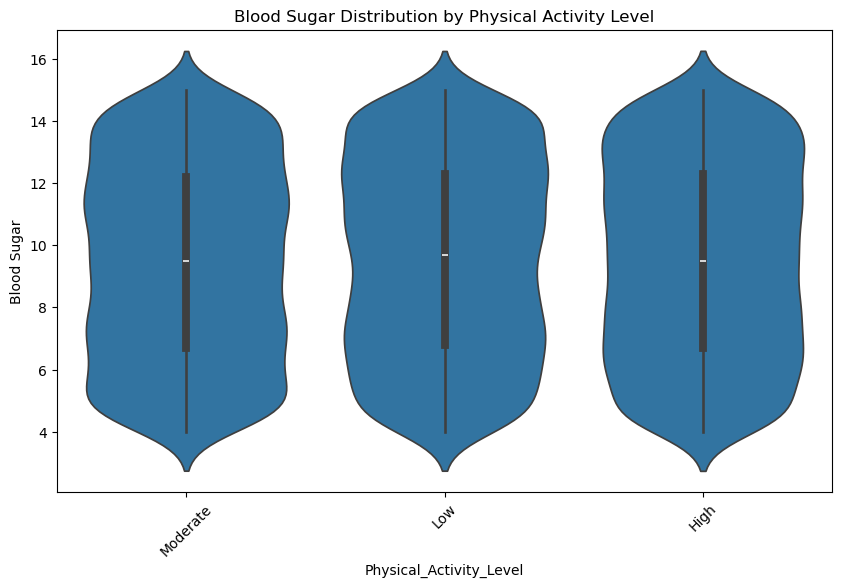

```python
#Violin Plot HbA1c(renamed Blood sugar) vs Activity lvl
plt.figure(figsize=(10, 6))
sns.violinplot(data=df, x="Physical_Activity_Level", y="Blood Sugar")
plt.title("Blood Sugar Distribution by Physical Activity Level")
plt.xticks(rotation=45)
plt.show()
```

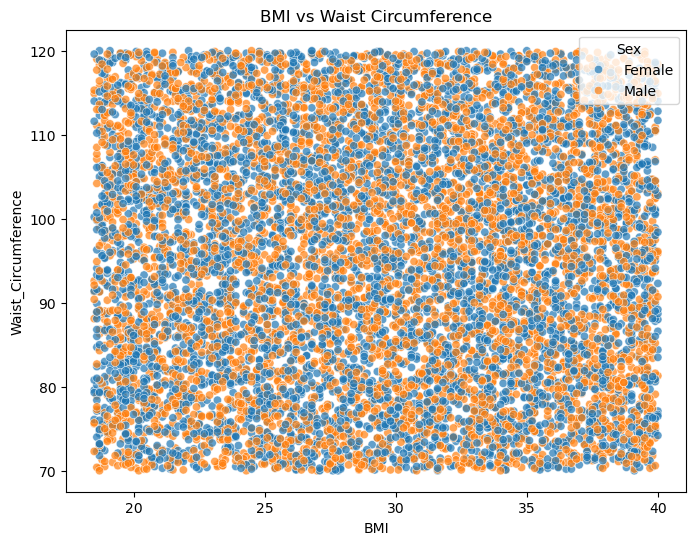

```python
#BMI vs Waist Circumference
plt.figure(figsize=(8, 6))
sns.scatterplot(data=df, x="BMI", y="Waist_Circumference", hue="Sex", alpha=0.7)
plt.title("BMI vs Waist Circumference")
plt.show()
```

### Extra visuals to intensely analyze BMI.

I spent a lot of time studying BMI in the dataset due to its known influence on Diabetes risk. Violin plots were the best method of visualization for these correlations because they also show shape through density, making it easier to see what bins differ a bit. A common trend in this section is that the different factorrs tend to differ only slightly, but that is still important to note as it sheds light on typical expectations. For example, alcohol consumption's expected influence on BMI does not seem to be as strong as some would expect. These visualizations would then help to deter negative stigmas or bad conclusions.

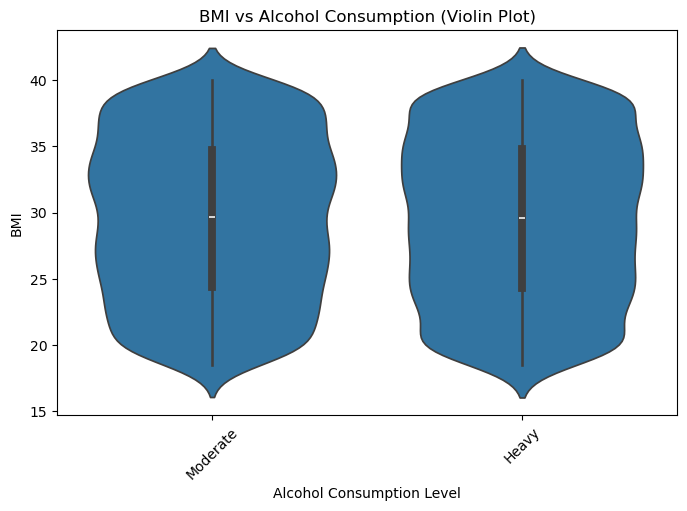

```python
#Extra visualizations. Alcohol consumption and BMI
plt.figure(figsize=(8, 5))
sns.violinplot(data=df, x="Alcohol_Consumption", y="BMI")
plt.title("BMI vs Alcohol Consumption (Violin Plot)")
plt.xlabel("Alcohol Consumption Level")
plt.ylabel("BMI")
plt.xticks(rotation=45)
plt.show()
```

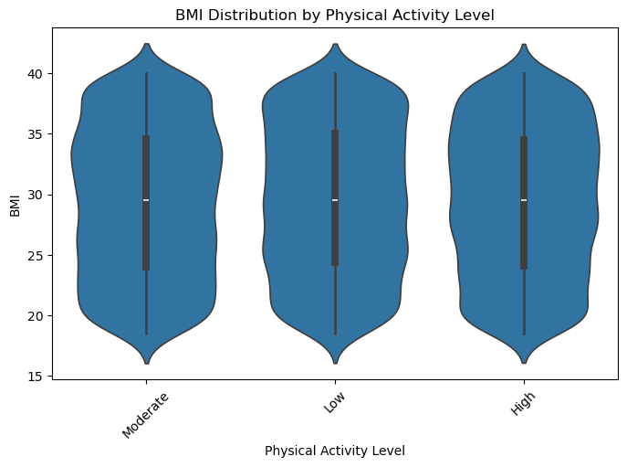

```python
#Violin plot for Presentation- Activity vs BMI
plt.figure(figsize=(8, 5))
sns.violinplot(data=df, x="Physical_Activity_Level", y="BMI")
plt.title("BMI Distribution by Physical Activity Level")
plt.xlabel("Physical Activity Level")
plt.ylabel("BMI")
plt.xticks(rotation=45)
plt.show()
```

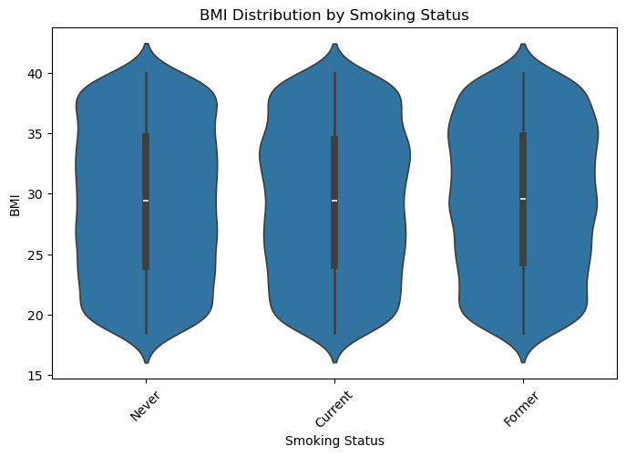

```python
#Violin plot for Presentation- Smoking Status vs BMI
plt.figure(figsize=(8, 5))
sns.violinplot(data=df, x="Smoking_Status", y="BMI",)
plt.title("BMI Distribution by Smoking Status")
plt.xlabel("Smoking Status")
plt.ylabel("BMI")
plt.xticks(rotation=45)
plt.show()
```

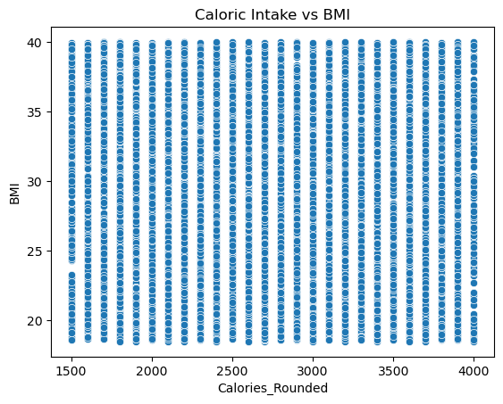

```python
#Scatterplot for Presentation- The reason the violin plot looked so weird was because the values are continuous numbers.
#I could either make a scatterplot or make bins for different caloric intake amounts (100-1500, 1500-2000, etc)
df['Calories_Rounded'] = df['Dietary_Intake_Calories'].round(-2)
sns.scatterplot(data=df, x="Calories_Rounded", y="BMI")
plt.title("Caloric Intake vs BMI")
#Tried a lot of different things and I think this best shows the distribution. I rounded the values to the nearest hundred
# Then I created a scatterpplot using the new column
```

## Conclusion

This dataset being so vast and thorough help to show why it is hard to predict diabetes or interpret risk factors today. Even with the differennt tupes of data, different contexts that they factor into (genetic vs lifestyle, etc), nothing seems to be a clear indicator of risk. As medical technology continues to improve, the future could hold more effective screening for diabetes risk, and this would help target prevention over treatment.